# 12处理时间序列数据和校正序列自相关

LJJ

2020/3/29

The purpose of this in-class lab12 is to use R to practice estimating **time series regression models** with standard errors corrected for heteroskedasticity and serial correlation (HAC). The lab11 should be completed in your group. To get credit, upload your .R script to the appropriate place on Canvas.

## 12.1 For starters

Load the usual packages, as well as the new ones installed in Lab 11.[^1]

Open up a new R script (named `ICL12_XYZ.R`, where `XYZ` are your initials) and add the usual “preamble” to the top:

```r
# Add names of group members HERE
library(tidyverse)
library(wooldridge)
library(broom)
library(car)
library(pdfetch)
library(zoo)
library(dynlm)
library(lmtest)
library(sandwich)
library(magrittr)
```

### 12.1.1 Load the data

We’re going to use data on US macroeconomic indicators. The `wooldridge` data set is called `phillips`.

```r
df <- as_tibble(phillips)
df %>% glimpse()
```

```
## Observations: 56
## Variables: 7
## $ year   <int> 1948, 1949, 1950, 1951, 1952, 1953, 1954, 1955, 1956, 1957, ...
## $ unem   <dbl> 3.8, 5.9, 5.3, 3.3, 3.0, 2.9, 5.5, 4.4, 4.1, 4.3, 6.8, 5.5, ...
## $ inf    <dbl> 8.1, -1.2, 1.3, 7.9, 1.9, 0.8, 0.7, -0.4, 1.5, 3.3, 2.8, 0.7...
## $ inf_1  <dbl> NA, 8.1, -1.2, 1.3, 7.9, 1.9, 0.8, 0.7, -0.4, 1.5, 3.3, 2.8,...
## $ unem_1 <dbl> NA, 3.8, 5.9, 5.3, 3.3, 3.0, 2.9, 5.5, 4.4, 4.1, 4.3, 6.8, 5...
## $ cinf   <dbl> NA, -9.3000002, 2.5000000, 6.6000004, -6.0000000, -1.0999999...
## $ cunem  <dbl> NA, 2.1000001, -0.5999999, -2.0000002, -0.3000000, -0.099999...
```

### 12.1.2 Declare `df` as time series data

```r
df.ts <- zoo(df, order.by=df$year)
```

Now it will be easy to include lags of various variables into our regression models.

## 12.2 Plot time series data

Let’s have a look at the **inflation rate** and **unemployment** for the US over the postwar period (1948–2003):

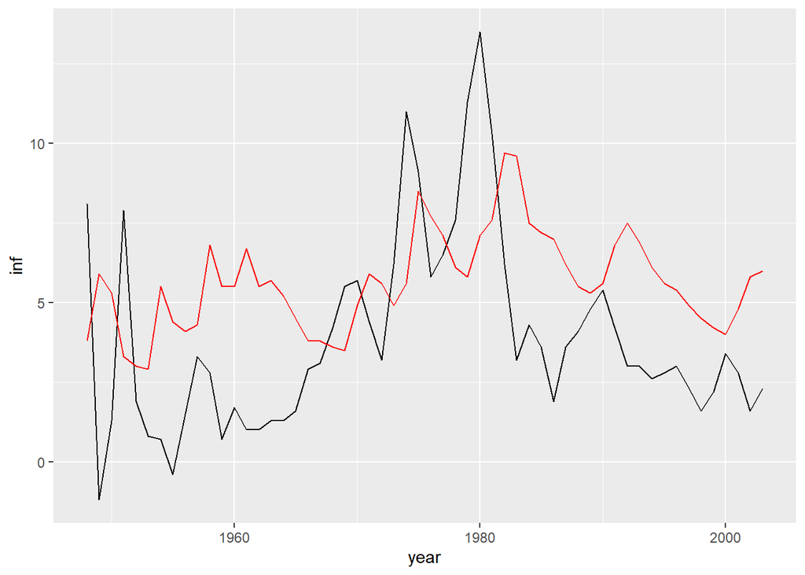

```r
ggplot(df.ts) +
  geom_line(aes(year, inf)) +
  geom_line(aes(year, unem), color="red")
```

## 12.3 Determinants of the inflation rate

Now let’s estimate the Phillips Curve:

$$inf_{t} = \beta_0 + \beta_1 unemp_t + u_t$$

where $inf$ is the inflation rate and $unem$ is the unemployment rate.

```r
library(tseries)
adf.test(df.ts$inf)  # alternative hypothesis: stationary
```

```
##
##  Augmented Dickey-Fuller Test
##
## data:  df.ts$inf
## Dickey-Fuller = -2.1213, Lag order = 3, p-value = 0.5257
## alternative hypothesis: stationary
```

```r
adf.test(df.ts$unem) # alternative hypothesis: stationary
```

```
##
##  Augmented Dickey-Fuller Test
##
## data:  df.ts$unem
## Dickey-Fuller = -2.2056, Lag order = 3, p-value = 0.4917
## alternative hypothesis: stationary
```

```r
est <- dynlm(inf ~ unem, data=df.ts)
```

1. Test for AR(1) serial correlation in this time series:

```r
dynlm(resid(est) ~ L(resid(est))) %>% coeftest()
```

```
##
## t test of coefficients:
##
##               Estimate Std. Error t value Pr(>|t|)
## (Intercept)   -0.11181    0.31799 -0.3516   0.7265
## L(resid(est))  0.57247    0.10835  5.2833 2.43e-06 ***
## ---
## Signif. codes:  0 '***' 0.001 '**' 0.01 '*' 0.05 '.' 0.1 ' ' 1
```

```r
dynlm(resid(est) ~ L(resid(est))) %>% broom::tidy()
```

```
## # A tibble: 2 x 5
##   term          estimate std.error statistic    p.value
##   <chr>            <dbl>     <dbl>     <dbl>      <dbl>
## 1 (Intercept)     -0.112     0.318    -0.352 0.727
## 2 L(resid(est))    0.572     0.108     5.28  0.00000243
```

Equivalently, you can use the `bgtest()` function in the `lmtest` package:

```r
bgtest(est)
```

```
##
##  Breusch-Godfrey test for serial correlation of order up to 1
##
## data:  est
## LM test = 20.888, df = 1, p-value = 4.87e-06
```

## 12.4 **Correcting for Serial Correlation**

Now let’s compute HAC (Heteroskedasticity and Autocorrelation Consistent) standard errors. To do so, we’ll use the `NeweyWest` option in the `coeftest()` function of the `lmtest` package.[^2]

```r
coeftest(est) # re-display baseline results
```

```
##
## t test of coefficients:
##
##             Estimate Std. Error t value Pr(>|t|)
## (Intercept)  1.05357    1.54796  0.6806  0.49902
## unem         0.50238    0.26556  1.8918  0.06389 .
## ---
## Signif. codes:  0 '***' 0.001 '**' 0.01 '*' 0.05 '.' 0.1 ' ' 1
```

```r
coeftest(est, vcov=NeweyWest)
```

```
##
## t test of coefficients:
##
##             Estimate Std. Error t value Pr(>|t|)
## (Intercept)  1.05357    1.56089  0.6750   0.5026
## unem         0.50238    0.36794  1.3654   0.1778
```

3. How does your interpretation of the effect of unemployment on inflation change, using the **Newey-West standard errors**?

### 12.4.1 Another way to correct for serial correlation

Another way to get rid of serial correlation is to *difference* the data. In this case, we will estimate the following regression:

$$\Delta inf_{t} = \beta_0 + \beta_1 unemp_t + u_t$$

where $\Delta inf_{t} = inf_{t}-inf_{t-1}$. Aside from addressing serial correlation, the differenced model also accounts for people’s inflationary expectations.

```r
est.diff <- dynlm(d(inf) ~ unem, data = df.ts)
```

4. Now perform a Breusch-Godfrey test on the differenced model. Is there a serial correlation problem?

```r
bgtest(est.diff)
```

```
##
##  Breusch-Godfrey test for serial correlation of order up to 1
##
## data:  est.diff
## LM test = 0.061273, df = 1, p-value = 0.8045
```

5. Compute the Newey-West SEs on the difference model. Are they much different from the baseline model?

```r
coeftest(est.diff)
```

```
##
## t test of coefficients:
##
##             Estimate Std. Error t value Pr(>|t|)
## (Intercept)  2.82820    1.22487  2.3090  0.02487 *
## unem        -0.51765    0.20904 -2.4763  0.01650 *
## ---
## Signif. codes:  0 '***' 0.001 '**' 0.01 '*' 0.05 '.' 0.1 ' ' 1
```

```r
coeftest(est.diff, vcov=NeweyWest)
```

```
##
## t test of coefficients:
##
##             Estimate Std. Error t value  Pr(>|t|)
## (Intercept)  2.82820    0.96385  2.9343 0.0049321 **
## unem        -0.51765    0.14717 -3.5173 0.0009031 ***
## ---
## Signif. codes:  0 '***' 0.001 '**' 0.01 '*' 0.05 '.' 0.1 ' ' 1
```

6. What do you conclude about the effect of unemployment on the *change in* inflation?
[^1]: You may need to install the `sandwich` package.
[^2]: `NeweyWest` comes from the `sandwich` package.